# Supervised machine learning

Pablo Barbera

September 26, 2017

### Regularized regression

Our running example will be a random sample of nearly 5,000 tweets mentioning the names of the candidates to the 2014 EP elections in the UK. We will be using a variable named `communication`, which indicates whether each tweet was hand-coded as being **engaging** (a tweet that tries to engage with the audience of the account) or **broadcasting** (just sending a message, without trying to elicit a response).

The source of the dataset is an article co-authored with Yannis Theocharis, Zoltan Fazekas, and Sebastian Popa, published in the Journal of Communication. The link is [here](http://onlinelibrary.wiley.com/doi/10.1111/jcom.12259/abstract). Our goal was to understand to what extent candidates are not engaging voters on Twitter because they’re exposed to mostly impolite messages.

Let’s start by reading the dataset and creating a dummy variable indicating whether each tweet is engaging

```r
library(quanteda)
tweets <- read.csv("../data/UK-tweets.csv", stringsAsFactors=F)
tweets$engaging <- ifelse(tweets$communication=="engaging", 1, 0)
tweets <- tweets[!is.na(tweets$engaging),]
```

We’ll do some cleaning as well – substituting handles with @. Why? We want to provent overfitting.

```r
tweets$text <- gsub('@[0-9_A-Za-z]+', '@', tweets$text)
```

As we discussed last week, before we can do any type of automated text analysis, we will need to go through several “preprocessing” steps before it can be passed to a statistical model. We’ll use the quanteda package quanteda here.

The basic unit of work for the quanteda package is called a corpus, which represents a collection of text documents with some associated metadata. Documents are the subunits of a corpus. You can use summary to get some information about your corpus.

```r
twcorpus <- corpus(tweets$text)
summary(twcorpus)
```

```
## Corpus consisting of 4566 documents, showing 100 documents.
##
##     Text Types Tokens Sentences
##    text1     8     10         2
##    text2    17     23         3
##    text3    15     18         2
##    text4    15     19         3
##    text5    14     15         1
##    text6     3      3         1
##    text7     9      9         1
##    text8    20     21         2
##    text9    20     23         5
##   text10     8      9         1
##   text11    15     20         1
##   text12    23     27         1
##   text13    16     27         1
##   text14    22     26         2
##   text15    12     19         1
##   text16    21     23         3
##   text17     9     14         1
##   text18    19     23         1
##   text19    18     20         1
##   text20    11     14         1
##   text21     6      6         1
##   text22    14     15         1
##   text23     8     10         1
##   text24     6      7         2
##   text25    29     33         1
##   text26    21     23         3
##   text27    16     18         2
##   text28    19     21         1
##   text29    15     21         1
##   text30    19     21         1
##   text31    20     22         1
##   text32    17     17         1
##   text33     7      7         1
##   text34    22     23         2
##   text35    18     20         2
##   text36    16     16         1
##   text37     9      9         1
```

[output cut: 52 more lines]

```
##   text90    11     13         1
##   text91    19     21         3
##   text92    27     31         3
##   text93    15     17         1
##   text94     5      5         1
##   text95     4      4         1
##   text96    28     29         2
##   text97     5      6         1
##   text98    22     24         1
##   text99    15     21         1
##  text100    24     27         1
##
## Source:  /Users/pablobarbera/git/POIR613/code/* on x86_64 by pablobarbera
## Created: Tue Sep 26 16:06:33 2017
## Notes:
```

We can then convert a corpus into a document-feature matrix using the dfm function. We will then trim it in order to keep only tokens that appear in 2 or more tweets. Note that we keep punctuation – it turns out it can be quite informative.

```r
twdfm <- dfm(twcorpus, remove=stopwords("english"), remove_url=TRUE,
             ngrams=1:2, verbose=TRUE)
```

```
## Creating a dfm from a corpus ...
```

```
##    ... tokenizing texts
```

```
##    ... lowercasing
```

```
##    ... found 4,566 documents, 48,721 features
```

```
## ...
```

```
## dfm_select removed 19,434 features and 0 documents, padding 0s for 0 features and 0 documents.
```

```
##    ... created a 4,566 x 29,287 sparse dfm
##    ... complete.
## Elapsed time: 25.9 seconds.
```

```r
twdfm <- dfm_trim(twdfm, min_docfreq = 2, verbose=TRUE)
```

```
## Removing features occurring:
```

```
##   - in fewer than 2 document: 22,883
```

```
##   Total features removed: 22,883 (78.1%).
```

Note that other preprocessing options are:

- remove_numbers
- remove_punct
- remove_twitter
- remove_symbols
- remove_separators

You can read more in the `dfm` and `tokens` help pages

Once we have the DFM, we split it into training and test set. We’ll go with 80% training and 20% set. Note the use of a random seed to make sure our results are replicable.

```r
set.seed(123)
training <- sample(1:nrow(tweets), floor(.80 * nrow(tweets)))
test <- (1:nrow(tweets))[1:nrow(tweets) %in% training == FALSE]
```

Our first step is to train the classifier using cross-validation. There are many packages in R to run machine learning models. For regularized regression, glmnet is in my opinion the best. It’s much faster than caret or mlr (in my experience at least), and it has cross-validation already built-in, so we don’t need to code it from scratch. We’ll start with a ridge regression:

```r
library(glmnet)
require(doMC)
```

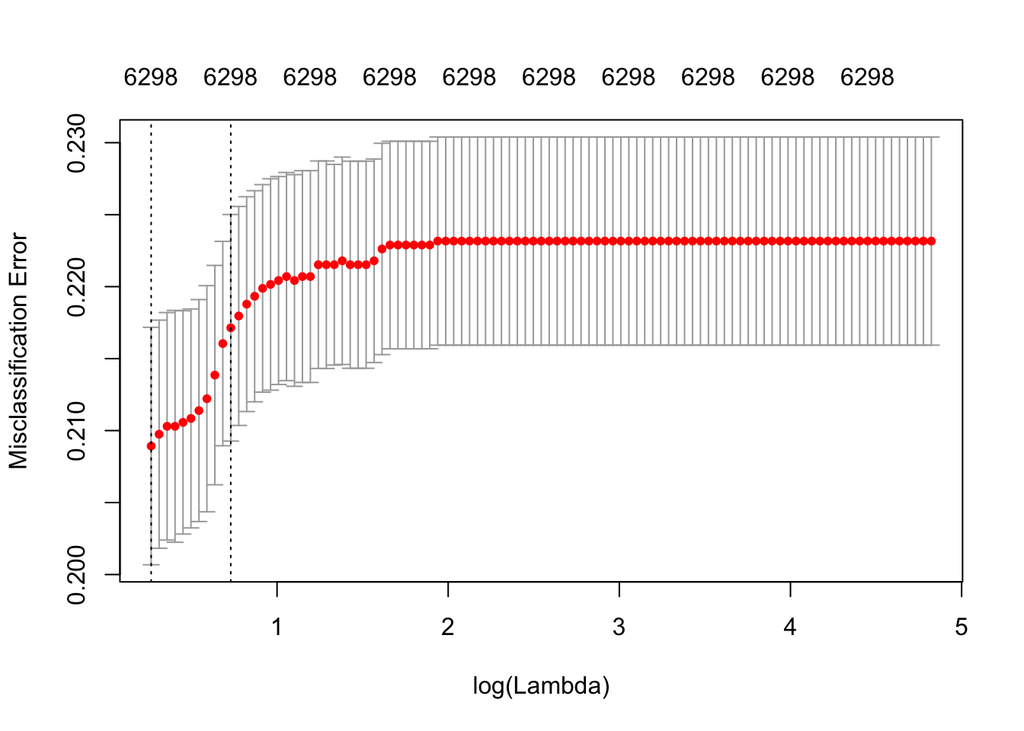

```r
registerDoMC(cores=3)
ridge <- cv.glmnet(twdfm[training,], tweets$engaging[training],
    family="binomial", alpha=0, nfolds=5, parallel=TRUE, intercept=TRUE,
    type.measure="class")
plot(ridge)
```

We can now compute the performance metrics on the test set.

```r
## function to compute accuracy
accuracy <- function(ypred, y){
    tab <- table(ypred, y)
    return(sum(diag(tab))/sum(tab))
}
# function to compute precision
precision <- function(ypred, y){
    tab <- table(ypred, y)
    return((tab[2,2])/(tab[2,1]+tab[2,2]))
}
# function to compute recall
recall <- function(ypred, y){
    tab <- table(ypred, y)
    return(tab[2,2]/(tab[1,2]+tab[2,2]))
}
# computing predicted values
preds <- predict(ridge, twdfm[test,], type="class")
# confusion matrix
table(preds, tweets$engaging[test])
```

```
##
## preds   0   1
##     0  11   2
##     1 182 719
```

```r
# performance metrics
accuracy(preds, tweets$engaging[test])
```

```
## [1] 0.7986871
```

```r
precision(preds, tweets$engaging[test])
```

```
## [1] 0.7980022
```

```r
recall(preds, tweets$engaging[test])
```

```
## [1] 0.9972261
```

Something that is often very useful is to look at the actual estimated coefficients and see which of these have the highest or lowest values:

```r
# from the different values of lambda, let's pick the highest one that is
# within one standard error of the best one (why? see "one-standard-error"
# rule -- maximizes parsimony)
best.lambda <- which(ridge$lambda==ridge$lambda.1se)
beta <- ridge$glmnet.fit$beta[,best.lambda]
head(beta)
```

```
##            @          @_@            .            ,            !
##  0.029413077  0.025527048  0.001848582 -0.003627634  0.009469734
##            -
## -0.015374536
```

```r
## identifying predictive features
df <- data.frame(coef = as.numeric(beta),
                word = names(beta), stringsAsFactors=F)

df <- df[order(df$coef),]
head(df[,c("coef", "word")], n=30)
```

```
##            coef                  word
## 3997 -0.3502883               reverse
## 5170 -0.3501177              knocking
## 4859 -0.3423031               managed
## 4787 -0.3409223                eu_law
## 6235 -0.3395205                cunt_.
## 3161 -0.3388851               posters
## 5529 -0.3371467               @_doing
## 3943 -0.3366187                beacon
## 5275 -0.3360461             ._they're
## 4351 -0.3352499           nationalism
## 5281 -0.3348163      populist_parties
## 4864 -0.3340288            determined
## 2584 -0.3331052            leafleting
## 5922 -0.3329338        euroscepticism
```

[output cut: 16 more lines]

```r
paste(df$word[1:30], collapse=", ")
```

```
## [1] "reverse, knocking, managed, eu_law, cunt_., posters, @_doing, beacon, ._they're, nationalism, populist_parties, determined, leafleting, euroscepticism, moving_!, lovely_messages, fame, cleaning, zone, #yes, nw_., laughed, defends, effective, god_,, scottish_independence, dick, one_person, to…
```

```r
df <- df[order(df$coef, decreasing=TRUE),]
head(df[,c("coef", "word")], n=30)
```

```
##           coef              word
## 5069 0.2059479         town_hall
## 2055 0.1647179              !_rt
## 2874 0.1637953           western
## 5024 0.1637902        west_green
## 4116 0.1633214            vote_-
## 4673 0.1556281     insignificant
## 4622 0.1498899                dt
## 4624 0.1498884              dt_@
## 2741 0.1465876              re_:
## 6232 0.1454278            seat_.
## 5762 0.1379470             :_new
## 3020 0.1362461            ;_thnx
## 3323 0.1328590             @_bbc
## 4568 0.1312390            ,_much
```

[output cut: 16 more lines]

```r
paste(df$word[1:30], collapse=", ")
```

```
## [1] "town_hall, !_rt, western, west_green, vote_-, insignificant, dt, dt_@, re_:, seat_., :_new, ;_thnx, @_bbc, ,_much, result_,, @_yougov, team_!, increase, !_&, prove, compliments, leave_eu, ._congratulations, great_piece, @_we've, #ukip_mep, addition, #badgercull, \"_don't, charges"
```

We can easily modify our code to experiment with Lasso or ElasticNet models:

```r
lasso <- cv.glmnet(twdfm[training,], tweets$engaging[training],
    family="binomial", alpha=1, nfolds=5, parallel=TRUE, intercept=TRUE,
    type.measure="class")
```

```r
# computing predicted values
preds <- predict(lasso, twdfm[test,], type="class")
# confusion matrix
table(preds, tweets$engaging[test])
```

```
##
## preds   0   1
##     0  44   6
##     1 149 715
```

```r
# performance metrics (slightly better!)
accuracy(preds, tweets$engaging[test])
```

```
## [1] 0.8304158
```

```r
precision(preds, tweets$engaging[test])
```

```
## [1] 0.8275463
```

```r
recall(preds, tweets$engaging[test])
```

```
## [1] 0.9916782
```

```r
best.lambda <- which(lasso$lambda==lasso$lambda.1se)
beta <- lasso$glmnet.fit$beta[,best.lambda]
head(beta)
```

```
##         @       @_@         .         ,         !         -
## 0.6748941 0.0000000 0.0000000 0.0000000 0.0000000 0.0000000
```

```r
## identifying predictive features
df <- data.frame(coef = as.numeric(beta),
                word = names(beta), stringsAsFactors=F)

df <- df[order(df$coef),]
head(df[,c("coef", "word")], n=30)
```

```
##            coef            word
## 203  -1.8155406            on_@
## 3633 -1.7398987     #voteni2014
## 106  -1.6224775           via_@
## 853  -1.5724760     #votelabour
## 149  -1.3057004          with_@
## 113  -1.2967362            to_@
## 129  -1.1918898           and_@
## 367  -1.0251529        hustings
## 70   -0.9180099         #ep2014
## 3620 -0.8247825           far_@
## 506  -0.7098486          hacked
## 191  -0.6606128            rt_@
## 3313 -0.6589735             (_@
## 383  -0.6568307 #labourdoorstep
```

[output cut: 16 more lines]

```r
df <- df[order(df$coef, decreasing=TRUE),]
head(df[,c("coef", "word")], n=30)
```

```
##            coef     word
## 22  0.682689751      @_i
## 1   0.674894097        @
## 13  0.452484535   thanks
## 44  0.293620973    thank
## 7   0.191427258        ?
## 141 0.173218648   @_good
## 74  0.148929010      :_-
## 25  0.090139103 @_thanks
## 86  0.076451338    @_yes
## 23  0.071765702     good
## 60  0.005819786    @_you
## 2   0.000000000      @_@
## 3   0.000000000        .
## 4   0.000000000        ,
```

[output cut: 16 more lines]

We now see that the coefficients for some features actually became zero.

```r
enet <- cv.glmnet(twdfm[training,], tweets$engaging[training],
    family="binomial", alpha=0.50, nfolds=5, parallel=TRUE, intercept=TRUE,
    type.measure="class")
# NOTE: this will not cross-validate across values of alpha

# computing predicted values
preds <- predict(enet, twdfm[test,], type="class")
# confusion matrix
table(preds, tweets$engaging[test])
```

```
##
## preds   0   1
##     0  73  18
##     1 120 703
```

```r
# performance metrics
accuracy(preds, tweets$engaging[test])
```

```
## [1] 0.8490153
```

```r
precision(preds, tweets$engaging[test])
```

```
## [1] 0.854192
```

```r
recall(preds, tweets$engaging[test])
```

```
## [1] 0.9750347
```

```r
best.lambda <- which(enet$lambda==enet$lambda.1se)
beta <- enet$glmnet.fit$beta[,best.lambda]
head(beta)
```

```
##         @       @_@         .         ,         !         -
## 0.6571334 0.0000000 0.0000000 0.0000000 0.0000000 0.0000000
```

```r
## identifying predictive features
df <- data.frame(coef = as.numeric(beta),
                word = names(beta), stringsAsFactors=F)

df <- df[order(df$coef),]
head(df[,c("coef", "word")], n=30)
```

```
##           coef              word
## 2654 -2.710506              nw_.
## 5781 -2.174327 @_#labourdoorstep
## 853  -2.134503       #votelabour
## 203  -2.118042              on_@
## 6275 -2.100751            meps_:
## 3633 -2.065081       #voteni2014
## 6299 -2.048960            meps_@
## 3620 -1.918778             far_@
## 3659 -1.875366               @_w
## 3313 -1.844906               (_@
## 3021 -1.756611             tries
## 2763 -1.733223            only_@
## 2535 -1.716515          password
## 367  -1.547533          hustings
```

[output cut: 16 more lines]

```r
df <- df[order(df$coef, decreasing=TRUE),]
head(df[,c("coef", "word")], n=30)
```

```
##            coef       word
## 22   0.94753021        @_i
## 1    0.65713339          @
## 74   0.55519984        :_-
## 86   0.49546459      @_yes
## 13   0.46661871     thanks
## 141  0.46064031     @_good
## 863  0.41931120 #votegreen
## 60   0.40343912      @_you
## 25   0.40022237   @_thanks
## 404  0.38919132    @_great
## 44   0.34696637      thank
## 57   0.34442865    @_thank
## 68   0.34223620      @_the
## 7    0.30753244          ?
```

[output cut: 16 more lines]

### Xgboost

If we really want the best performance at a low computational cost, the cutting-edge method many people are using is Distributed Gradient Boosting, based on the same ideas as boosted trees / random forests, implemented as `xgboost`. You can read more about the history of this package [here](https://homes.cs.washington.edu/~tqchen/2016/03/10/story-and-lessons-behind-the-evolution-of-xgboost.html).

First, let’s prepare the data…

```r
library(quanteda)
tweets <- read.csv("../data/UK-tweets.csv", stringsAsFactors=F)
tweets$engaging <- ifelse(tweets$communication=="engaging", 1, 0)
tweets <- tweets[!is.na(tweets$engaging),]
# clean text and create DFM
tweets$text <- gsub('@[0-9_A-Za-z]+', '@', tweets$text)
twcorpus <- corpus(tweets$text)
twdfm <- dfm(twcorpus, remove=stopwords("english"), remove_url=TRUE,
             ngrams=1:2, verbose=TRUE)
```

```
## Creating a dfm from a corpus ...
```

```
##    ... tokenizing texts
```

```
##    ... lowercasing
```

```
##    ... found 4,566 documents, 48,721 features
```

```
## ...
```

```
## dfm_select removed 19,434 features and 0 documents, padding 0s for 0 features and 0 documents.
```

```
##    ... created a 4,566 x 29,287 sparse dfm
##    ... complete.
## Elapsed time: 27.3 seconds.
```

```r
twdfm <- dfm_trim(twdfm, min_docfreq = 2, verbose=TRUE)
```

```
## Removing features occurring:
```

```
##   - in fewer than 2 document: 22,883
```

```
##   Total features removed: 22,883 (78.1%).
```

```r
# training and test sets
set.seed(123)
training <- sample(1:nrow(tweets), floor(.80 * nrow(tweets)))
test <- (1:nrow(tweets))[1:nrow(tweets) %in% training == FALSE]
```

Now we can train the model:

```r
library(xgboost)
# converting matrix object
X <- as(twdfm, "dgCMatrix")
# parameters to explore
tryEta <- c(1,2)
tryDepths <- c(1,2,4)
# placeholders for now
bestEta=NA
bestDepth=NA
bestAcc=0

for(eta in tryEta){
  for(dp in tryDepths){
    bst <- xgb.cv(data = X[training,],
            label =  tweets$engaging[training],
            max.depth = dp,
          eta = eta,
          nthread = 4,
          nround = 500,
          nfold=5,
          print_every_n = 100L,
          objective = "binary:logistic")
    # cross-validated accuracy
    acc <- 1-mean(tail(bst$evaluation_log$test_error_mean))
        cat("Results for eta=",eta," and depth=", dp, " : ",
                acc," accuracy.\n",sep="")
        if(acc>bestAcc){
                bestEta=eta
                bestAcc=acc
                bestDepth=dp
        }
    }
}
```

```
## Results for eta=1 and depth=1 : 0.8829353 accuracy.
## Results for eta=1 and depth=2 : 0.8804297 accuracy.
## Results for eta=1 and depth=4 : 0.8800171 accuracy.
## Results for eta=2 and depth=1 : 0.5665086 accuracy.
## Results for eta=2 and depth=2 : 0.708116 accuracy.
## Results for eta=2 and depth=4 : 0.7930559 accuracy.
```

```r
cat("Best model has eta=",bestEta," and depth=", bestDepth, " : ",
    bestAcc," accuracy.\n",sep="")
```

```
## Best model has eta=1 and depth=1 : 0.8829353 accuracy.
```

How well does it perform out-of-sample?

```r
# running best model
rf <- xgboost(data = X[training,],
    label = tweets$engaging[training],
        max.depth = bestDepth,
    eta = bestEta,
    nthread = 4,
    nround = 1000,
        print_every_n=100L,
    objective = "binary:logistic")
# out-of-sample accuracy
preds <- predict(rf, X[test,])

## function to compute accuracy
accuracy <- function(ypred, y){
    tab <- table(ypred, y)
    return(sum(diag(tab))/sum(tab))
}
# function to compute precision
precision <- function(ypred, y){
    tab <- table(ypred, y)
    return((tab[2,2])/(tab[2,1]+tab[2,2]))
}
# function to compute recall
recall <- function(ypred, y){
    tab <- table(ypred, y)
    return(tab[2,2]/(tab[1,2]+tab[2,2]))
}

cat("\nAccuracy on test set=", round(accuracy(preds>.50, tweets$engaging[test]),3))
```

```
##
## Accuracy on test set= 0.869
```

```r
cat("\nPrecision on test set=", round(precision(preds>.50, tweets$engaging[test]),3))
```

```
##
## Precision on test set= 0.907
```

```r
cat("\nRecall on test set=", round(recall(preds>.50, tweets$engaging[test]),3))
```

```
##
## Recall on test set= 0.929
```

What we sacrifice is interpretability (yet again!). We can check feature importance, but it’s often hard to tell what’s going on exactly. Why? We only what features “matter”, but not why!

```r
# feature importance
labels <- dimnames(X)[[2]]
importance <- xgb.importance(labels, model = rf, data=X, label=tweets$engaging)
importance <- importance[order(importance$Gain, decreasing=TRUE),]
head(importance, n=20)
```

```
##         Feature        Split        Gain       Cover Frequency RealCover
##  1:           @           18 0.317075959 0.005701276     0.003       979
##  2:         @_@           16 0.070935824 0.002328724     0.001       530
##  3:         @_:            4 0.039597797 0.009091385     0.008        30
##  4:       via_@ -9.53674e-07 0.037202199 0.003077324     0.002         4
##  5:      with_@            4 0.026151768 0.001795029     0.001         3
##  6:        to_@ -9.53674e-07 0.023263293 0.003530451     0.003        10
##  7:      thanks          1.5 0.017029328 0.004719396     0.004       128
##  8:     #ep2014 -9.53674e-07 0.016931430 0.002705811     0.002         9
##  9:        @_is            4 0.015453980 0.002405848     0.002        12
## 10:        on_@            4 0.014059682 0.006254939     0.006         2
## 11:           @          8.5 0.013889075 0.001662281     0.001       991
## 12:           ?           16 0.011642680 0.001452536     0.001       217
## 13:         @_i -9.53674e-07 0.010909844 0.006573625     0.006        99
## 14:         @_' -9.53674e-07 0.010605283 0.001436444     0.001         8
```

[output cut: 27 more lines]

```r
# adding sign
sums <- list()
for (v in 0:1){
    sums[[v+1]] <- colSums(X[tweets[,"engaging"]==v,])
}
sums <- do.call(cbind, sums)
sign <- apply(sums, 1, which.max)

df <- data.frame(
    Feature = labels,
    sign = sign-1,
    stringsAsFactors=F)
importance <- merge(importance, df, by="Feature")

## best predictors
for (v in 0:1){
    cat("\n\n")
    cat("value==", v)
    importance <- importance[order(importance$Gain, decreasing=TRUE),]
    print(head(importance[importance$sign==v,], n=50))
    cat("\n")
    cat(paste(unique(head(importance$Feature[importance$sign==v], n=50)), collapse=", "))
}
```

```
##
##
## value== 0            Feature        Split         Gain       Cover Frequency
##  1:           via_@ -9.53674e-07 0.0372021989 0.003077324     0.002
##  2:          with_@            4 0.0261517677 0.001795029     0.001
##  3:            to_@ -9.53674e-07 0.0232632932 0.003530451     0.003
##  4:         #ep2014 -9.53674e-07 0.0169314299 0.002705811     0.002
##  5:            on_@            4 0.0140596818 0.006254939     0.006
##  6:             @_' -9.53674e-07 0.0106052830 0.001436444     0.001
##  7:           today            4 0.0103340378 0.002378009     0.002
##  8:           and_@            4 0.0079150306 0.001422331     0.001
##  9:     #votelabour -9.53674e-07 0.0076985374 0.003470392     0.003
## 10:           green          1.5 0.0069683712 0.001379948     0.001
## 11:          hacked -9.53674e-07 0.0062636103 0.004351157     0.004
## 12:            meet            4 0.0051424163 0.003338398     0.003
```

[output cut: 200 more lines]